# INFO 370A HW 1: Review of Prerequisite Knowledge

Name: Trevor Bruecher

This is a R Notebook. Execute this chunk by clicking the *Run* button within the chunk or by placing your cursor inside it and pressing *Cmd+Shift+Enter*.

Read more about it in Chapter 12 of the [INFO 201 textbook](https://info201.github.io/)

### 1) Write 3 things from the INFO 201 textbook that were confusing:

1.1) Vectors start at index 1 rather than 0 which I am used to with arrays.

1.2)I was confused by the dplyr Library because I have never used it before.

1.3) Im not sure which APIs to use in R yet.

### Vectors

```r
# Set variable vec_even to a vector of even numbers from 2 to 100 (inclusive).
vec_even <- seq(2, 100, 2)
# Set variable vec_odd to a vector of odd numbers from 1 to 99 (inclusive).
vec_odd <- seq(1, 100, 2)
# Set variable vec_sum to the sum of vec_even and vec_odd.
vec_sum <- vec_even + vec_odd
# Work on 2.1 below
get_upper <- function(nums) {
  num_mean = mean(nums)
  count <- 0
  for (num in nums) {
    if(num > num_mean) {
      count <- count + 1
    }
  }
  return (count);
}
print(get_upper(vec_sum))
```

```
[1] 25
```

How many values in vec_sum are greater than the mean?

2.1) *TODO*: Write a function get_upper which takes in a vector of numbers and returns the number of values which are greater than the mean. So get_upper(c(1,3,2,5)) would return 2.

2.2) *TODO*: How many values in vec_sum are greater than the mean? 25

### Importing libraries

Now we’re just importing some libraries. If you get errors when you run this, you may need to install some packages (see Ch 10.2).

```r
library(MASS) # access to Boston data frame
data(mtcars) # data on motor trend car road tests
library(dplyr) # data wrangling package. See Chapter 10 in INFO 201 textbook
library(ggplot2) # plotting library. See Chapter 13 of INFO 201 textbook
```

### Learning about Vehicle Efficiancy

We will now play with some data from 1974 Motor Trend Car Road Tests. The data exists in a dataframe *mtcars*.

```r
?mtcars # learn more about the dataframe
View(mtcars) # see the dataframe

#3.1
print(mean(mtcars[["hp"]]))
```

```
[1] 146.6875
```

```r
#3.2
print(mean(filter(mtcars, cyl == 4)[["hp"]]))
```

```
[1] 82.63636
```

```r
#3.3
print(mean(filter(mtcars, disp >= 100, disp <= 200)[["mpg"]]))
```

```
[1] 21.6
```

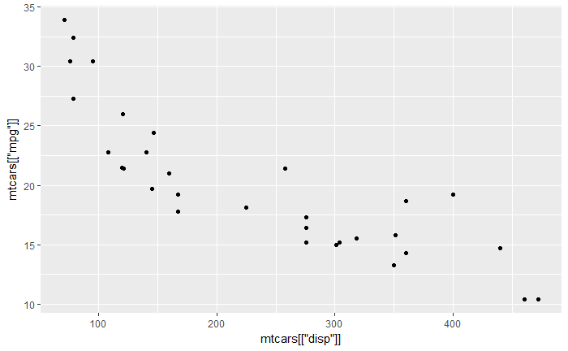

```r
#3.4
ggplot(data = mtcars) +
  geom_point(mapping = aes(x = mtcars[["disp"]], y = mtcars[["mpg"]]))
```

What is the mean horsepower for all cars? 3.1) 146.6875 hp

What is the mean horsepower for cars with 4 cylinders? 3.2) 82.63636 hp

What is the mean fuel efficiency (in MPG) for cars with a displacement between 100 and 200 cu. in.? 3.3) 21.6 mpg

3.4) *TODO*: Use ggplot to plot the relationship between vehicle displacement (x-axis) and miles per gallon (y-axis)

Our friends in Europe now want to see this data but they want it converted to metric!

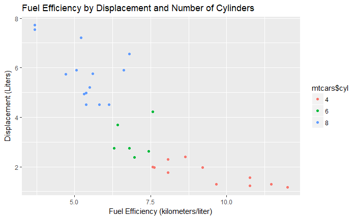

```r
#conversion ratios
MPG_KML_RATIO <- 0.35400619 # 1 Miles/Gallon = 0.35 Kilometer/Liter
CIN_L_RATIO <- 0.0163871 # 1 cubic inch = 0.016 Liter
# Add a column "kml" to the mtcars dataframe which provides the kilometers / liter for each car. The conversion from MPG to KML is provided by MPG_KML_RATIO.
mtcars$kml <- mtcars[["mpg"]] * MPG_KML_RATIO

# Add a column "disp_l" to the mtcars dataframe which provides the displacement for each car in liters. The conversion from cubic inches to liters is provided by CIN_L_RATIO.
mtcars$disp_l <- mtcars[["disp"]] * CIN_L_RATIO
# Convert mtcars$cyl to a factor (see Chapter 9.3)
mtcars$cyl <- as.factor(mtcars$cyl)
# Show 4.1 and 4.2 below!
#4.1
ggplot(data = mtcars) +
  geom_point(mapping = aes(x = mtcars$kml, y = mtcars$disp_l, color = mtcars$cyl)) +
  labs(title = "Fuel Efficiency by Displacement and Number of Cylinders",
       x = "Fuel Efficiency (kilometers/liter)",
       y = "Displacement (Liters)")
```

4.1) *TODO* Use ggplot to plot the relationship between vehicle displacement in liters and kilometers/liter. Color the points by number of cylinder. Give the plot a title, label both axes.

Based on your plot in 4.1, comment on the relationship between displacement, fuel efficiency, and cylinders. 4.2) Cars with more cylinders tend to have lower fuel efficiency and higher displacement compared to cars with only 4 cylinders that have high fuel efficiency and low displacement.

### Looking at Boston housing data

```r
# Work on 5.1-5.3 below
?Boston # getting more information on the dataset
boston <- Boston
View(boston) # Viewing data
#5.2
print(Tract <- filter(boston, chas == 1) %>%
  arrange(-crim) %>%
  head(5) %>%
  select(medv))
```

|  | medv |
| --- | --- |
| 1 | 17.8 |
| 2 | 50.0 |
| 3 | 50.0 |
| 4 | 50.0 |
| 5 | 22.7 |

```r
#5.3
print(NoTract <- filter(boston, chas == 0) %>%
  arrange(-crim) %>%
  head(5) %>%
  select(medv))
```

|  | medv |
| --- | --- |
| 1 | 10.4 |
| 2 | 8.8 |
| 3 | 5.0 |
| 4 | 15.0 |
| 5 | 7.0 |

What does a row in the Boston dataset represent? 5.1) The housing value for one town/suburb of Boston.

What is the median value of owner-occupied homes for the 5 neighborhoods with the highest per capita crime rate that tract bound the Charles River? (hint: see Chapter 10) 5.2) 50

What is the median value of owner-occupied homes for the 5 neighborhoods with the highest per capita crime rate that do NOT tract bound the Charles River? 5.3) 8.8

Last question: How long did this assignment take you? 6.1) 3 hours

That’s it for this assignment. Great job!